# 4_SVM

2023-02-03

## Support Vector Machines

### Tunning de support vector machines o SVM

#### SVM Lineal

Para el SVM lineal se necesita la constante de regularización C. A continuación se construyen un par de modelos buscando un valor C optimo utilizando las variables seleccionadas con *stepwise*:

Como en los modelos anteriores, se utiliza el archivo dengue.RDS que contiene los datos preprocesados

```r
# Carga de datos
dengue <- readRDS(file = "./data/processed/dengue.rds")
```

```r
# 1. SVM -------------
# 1.1 SVM lineal -----

SVMgrid <- expand.grid(C = c(0.01, 0.05, 0.1, 0.2, 0.5, 1, 2, 5, 10))
set.seed(12345)
control_svm <- trainControl(method = "cv", number = 4, savePredictions = "all")

svm_1 <-train(
    data = dengue,
    factor(varObjBin) ~ h10pix + temp90 + trees + trees90 + Ymin +
    Ymax + temp + humid + humid90,
    method = "svmLinear",
    trControl = control_svm,
    tuneGrid = SVMgrid,
    verbose = FALSE)
```

Se muestran los resultados y el gráfico correspondiente

```r
#svm_1
knitr::kable(svm_1$results, "pipe")
```

| C | Accuracy | Kappa | AccuracySD | KappaSD |
| --- | --- | --- | --- | --- |
| 0.01 | 0.8826781 | 0.7639678 | 0.0019727 | 0.0047681 |
| 0.05 | 0.8907305 | 0.7804037 | 0.0061257 | 0.0123735 |
| 0.10 | 0.8907295 | 0.7801867 | 0.0073525 | 0.0145912 |
| 0.20 | 0.8917365 | 0.7820591 | 0.0071642 | 0.0142584 |
| 0.50 | 0.8937506 | 0.7860458 | 0.0069711 | 0.0137572 |
| 1.00 | 0.8947566 | 0.7880580 | 0.0082336 | 0.0165615 |
| 2.00 | 0.8942526 | 0.7869114 | 0.0090433 | 0.0185537 |
| 5.00 | 0.8932476 | 0.7848042 | 0.0076308 | 0.0159467 |
| 10.00 | 0.8932466 | 0.7847956 | 0.0084889 | 0.0177490 |

```r
svm_1$bestTune
```

```
##   C
## 6 1
```

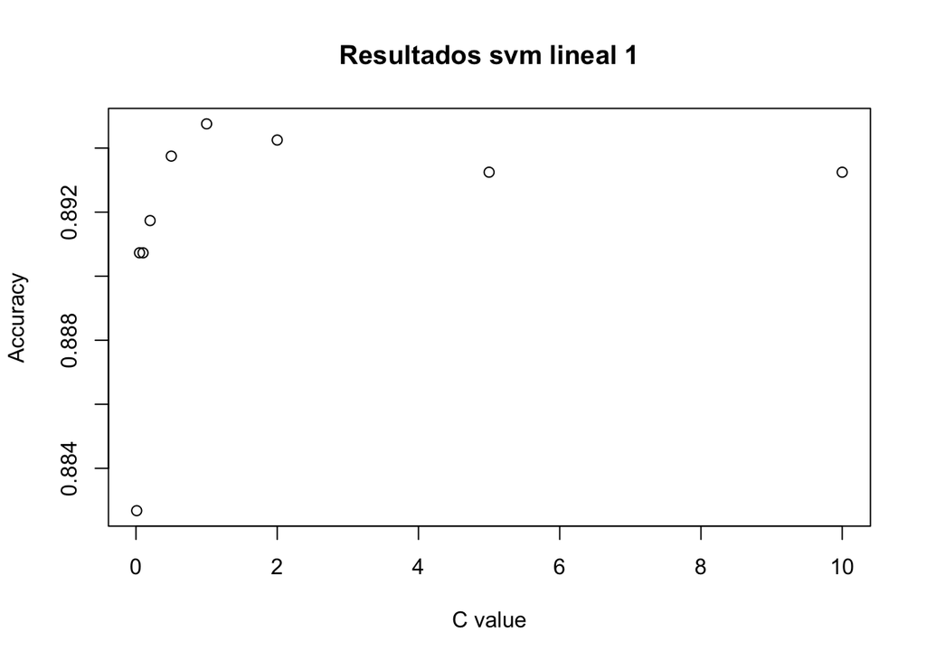

```r
plot(svm_1$results$C, svm_1$results$Accuracy, xlab = "C value", ylab = "Accuracy",
     main = "Resultados svm lineal 1")
```

Observando bestTune y el gráfico, para este primer modelado de svm el valor C mas adecuado estaría entre 0.20 y 2 (donde se observa mejor *accuracy* en tabla), caret en bestTune indica un valor de C de 1 que es también lo que se observa en el gráfico. Con este nuevo valor de C se construye otro modelo donde se busca si es que hay un mejor valor de C en un grid de 0.1 hasta 1

```r
SVMgrid_1 <- expand.grid(C = c(0.1, 0.2, 0.3, 0.4, 0.6, 0,7, 0.8, 0.9, 1))

svm_2 <- train(
    data = dengue,
    factor(varObjBin) ~ h10pix + temp90 + trees + trees90 + Ymin +
    Ymax + temp + humid + humid90,
    method = "svmLinear",
    trControl = control_svm,
    tuneGrid = SVMgrid_1,
    verbose = FALSE)
```

Se despliegan los resultados

| C | Accuracy | Kappa | AccuracySD | KappaSD |
| --- | --- | --- | --- | --- |
| 0.0 | NaN | NaN | NA | NA |
| 0.1 | 0.8887225 | 0.7759217 | 0.0149168 | 0.0299117 |
| 0.2 | 0.8897305 | 0.7778107 | 0.0160410 | 0.0321021 |
| 0.3 | 0.8902325 | 0.7787794 | 0.0151992 | 0.0304367 |
| 0.4 | 0.8902325 | 0.7787794 | 0.0151992 | 0.0304367 |
| 0.6 | 0.8912386 | 0.7807338 | 0.0139547 | 0.0278815 |
| 0.8 | 0.8912386 | 0.7807338 | 0.0139547 | 0.0278815 |
| 0.9 | 0.8912386 | 0.7807338 | 0.0139547 | 0.0278815 |
| 1.0 | 0.8922446 | 0.7828480 | 0.0129108 | 0.0256217 |
| 7.0 | 0.8907325 | 0.7797644 | 0.0103568 | 0.0203075 |

```
##   C
## 9 1
```

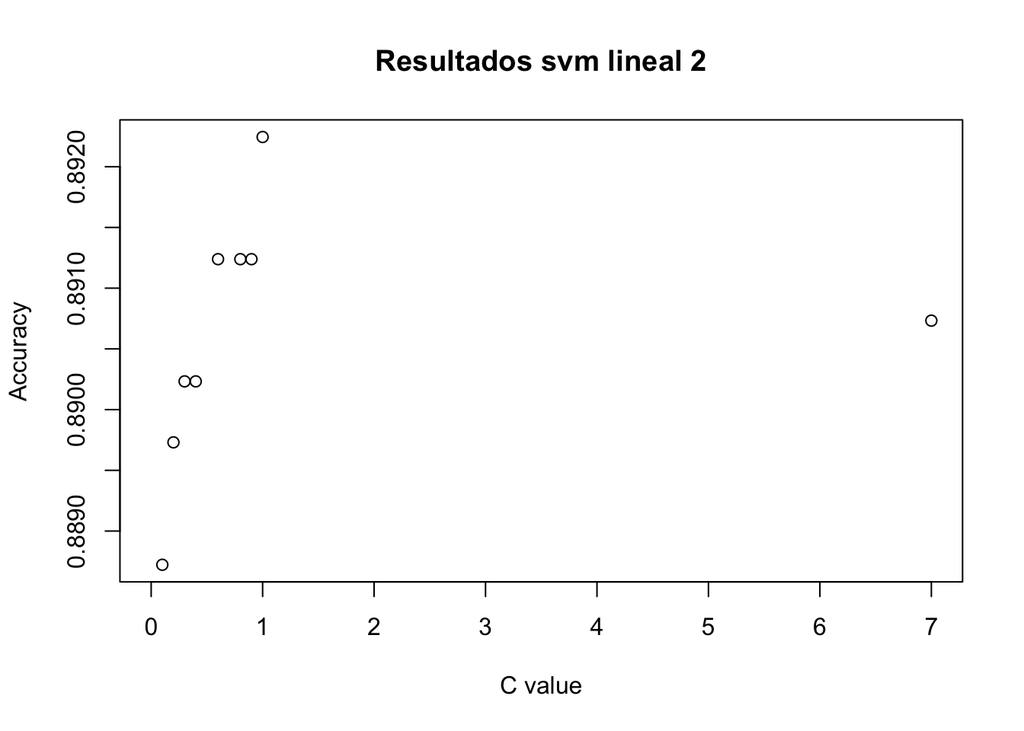

Para este dataset con SVM lineal el valor de C mas adecuado seria C=1.

#### SVM Polinomial

En este segundo apartado se utiliza un kernel polinomial buscando el valor de C, el grado del polinomio y la escala (C, degree y scale respectivamente), se entrena el modelo:

```r
# 1.2 SVM Polinomial ----
SVMgrid_p <- expand.grid(
    C = c(0.01, 0.05, 0.1, 0.2, 0.5, 1, 2, 5, 10),
    degree = c(2, 3),
    scale = c(0.1, 0.5, 1, 2, 5))

svm_3 <- train(
    data = dengue,
    factor(varObjBin) ~ h10pix + temp90 + trees + trees90 +
    Ymin + Ymax + temp + humid + humid90,
    method = "svmPoly",
    trControl = control_svm,
    tuneGrid = SVMgrid_p,
    verbose = FALSE)
```

Se despliegan los resultados

|  | degree | scale | C |
| --- | --- | --- | --- |
| 49 | 3 | 2 | 0.5 |

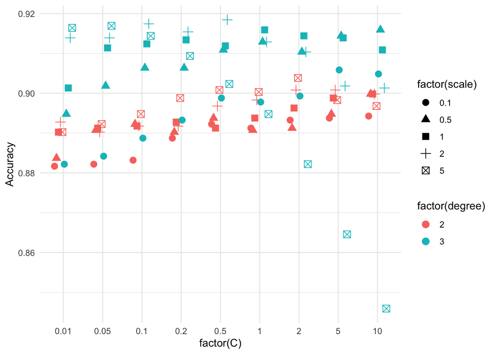

En los resultados con bestTune se sugiere un degree de 3, scale 2 y un c value de 0.5. En el gráfico los mejores resultados en *accuracy* los muestra con degree 3, para c value muestra buenos resultados de 0.5 en adelante.

Como los mejores resultados los da el degree 3, se muestra un nuevo gráfico con ese grado y realizar observaciones:

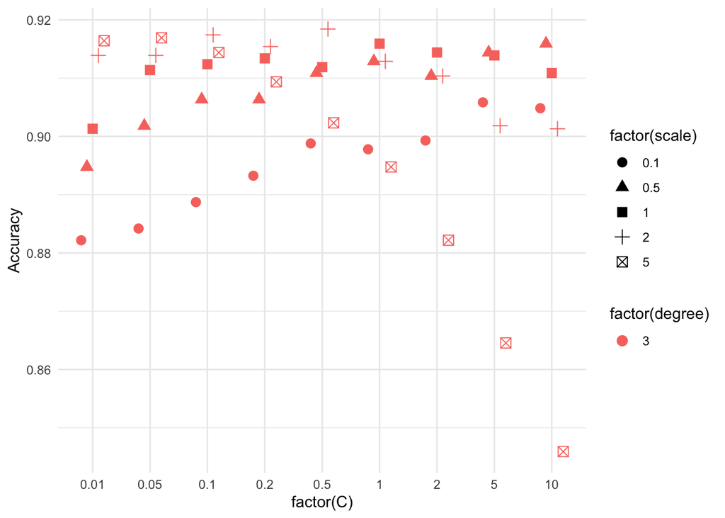

En general scale tiende a generar una curva hasta el valor C=0.5 y después descender para volver a alcanzar un accuracy alto en C=10. Como un C muy grande puede tender al sobreajuste para este dataset es mejor un C 0,5 o 1 y escala 2

#### SVM RBF

En este tercer apartado se agrega al c value el parámetro sigma de varianza-escala buscando el valor gamma/sigma mas adecuado para este modelo. Gamma: a mayor gamma se puede presentar sobreajuste.

```r
# 1.3 SVM RBF --------
#Se agrega el parametro sigma
SVMgrid_rbf <- expand.grid(
    C = c(0.01, 0.05, 0.1, 0.2, 0.5, 1, 2, 5, 10, 30),
    sigma = c(0.01, 0.05, 0.1, 0.2, 0.5, 1, 2, 5, 10, 30)
)

svm_4 <- train(
    data = dengue, factor(varObjBin) ~ h10pix + temp90 + trees + trees90 +
    Ymin + Ymax + temp + humid + humid90,
    method = "svmRadial",
    trControl = control_svm,
    tuneGrid = SVMgrid_rbf,
    verbose = FALSE)
```

Se despliegan los resultados

|  | sigma | C |
| --- | --- | --- |
| 95 | 0.5 | 30 |

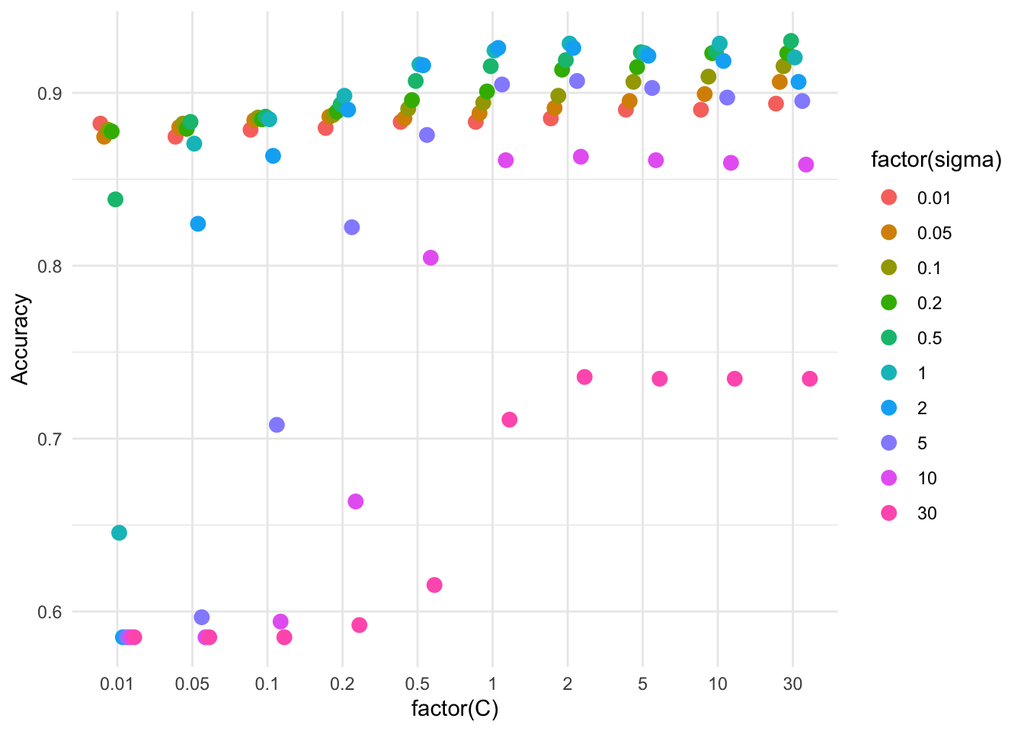

- A mayor sigma (10, 30) no se observa que los resultados mejoren en términos de *accuracy.*
- bestTune recomienda un sigma de 0.5 y un C de 30, pero desde c 1 hasta c 30 los resultados se observan relativamente parejos por lo que se mantiene el dejar el valor c en 1 y un sigma de 0.5

### Validacion cruzada para support vector machines

Con los valores obtenidos de svm lineal, polinomial y RBF se realiza la validación cruzada para su posterior ploteo y comparación de medias para este modelo versus los generados con los algoritmos anteriores

```r
# 2. Validacion cruzada rep SVM -------------------------------------------
#cv para lineal
medias14 <- cruzadaSVMbin(
    data = dengue,
    vardep = "varObjBin",
    listconti = c("h10pix", "temp90", "trees", "trees90",
    "Ymin", "Ymax", "temp", "humid", "humid90"),
    listclass = c(""),
    grupos = 4,
    sinicio = 1234,
    repe = 5,
    C = 1
)

medias14$modelo <- "svmLineal"

# cv para poli
medias15 <- cruzadaSVMbinPoly(
    data = dengue,
    vardep = "varObjBin",
    listconti = c("h10pix", "temp90", "trees", "trees90",
    "Ymin", "Ymax", "temp", "humid", "humid90"),
    listclass = c(""),
    grupos = 4,
    sinicio = 1234,
    repe = 5,
    C = 0.5,
    degree = 3,
    scale = 2
)

medias15$modelo <- "svmPoly"

# cv RBF
medias16 <- cruzadaSVMbinRBF(
    data = dengue,
    vardep = "varObjBin",
    listconti = c("h10pix", "temp90", "trees", "trees90",
    "Ymin", "Ymax", "temp", "humid", "humid90"),
    listclass = c(""),
    grupos = 4,
    sinicio = 1234,
    repe = 5,
    C = 1,
    sigma = 0.5
)

medias16$modelo <- "svmRBF"
```

### Comparacion de medias y boxplot

Utilizando la función genera_graficos() se despliega el gráfico de comparación de medias

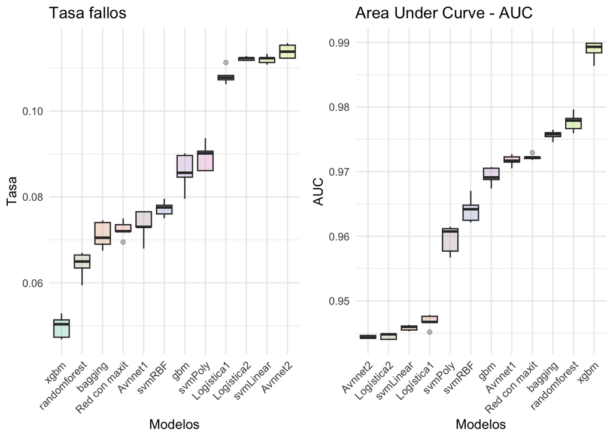

```r
genera_graficos(medias1,medias2,medias3, medias4, medias5,medias6, medias11, medias12,
    medias13, medias14,medias15, medias16)
```

**Observaciones**

- De los tres modelos el que presenta mayor varianza es el modelo polinomial, los resultados en accuracy sobre todo en svmRBF son buenos pero sigue siendo hasta ahora un randomForest o un xgbm (solo observando el gráfico) los que mejores resultados entregan.